# Old Faithlful Prediction Application

Kenney Snell  
January 9, 2018

## Description

This Shiny Application predicts the duration (minutes) of the next eruption of Old Faithful. Use the slider to enter the waiting time (minutes) between eruptions. The applicaiton uses linear regression and machine learning to predict the duration of next eruption.

## Inputs:

- Duration time since the last eruption
- Display Method 1 - Uses Linear Regression
- Display Method 2 - Uses the caret(train) Machine Learning method rlm (robust linear model)

## Outputs

- Graph showing the fitted line for both methods and the predicted point on the line.
- pred1: Prediction (minutes) for the next eruption using method 1.
- pred2: Prediction (minutes) for the next eruption using method 2.

## Data Description

Waiting time between eruptions and the duration of the eruption for the Old Faithful geyser in Yellowstone National Park, Wyoming, USA. faithful: A data frame with 272 observations on 2 variables. [,1] eruptions numeric Eruption time in mins [,2] waiting numeric Waiting time to next eruption (in mins)

```r
library(caret)
library(klaR)
data("faithful")
inTrain <- createDataPartition(y=faithful$waiting,
                               p=0.7, list=FALSE)
trainFaith <- faithful[inTrain,]
testFaith <- faithful[-inTrain,]
summary(testFaith)
```

```
   eruptions        waiting
 Min.   :1.667   Min.   :48.00
 1st Qu.:2.071   1st Qu.:57.75
 Median :4.016   Median :76.00
 Mean   :3.507   Mean   :71.70
 3rd Qu.:4.391   3rd Qu.:82.00
 Max.   :5.100   Max.   :96.00
```

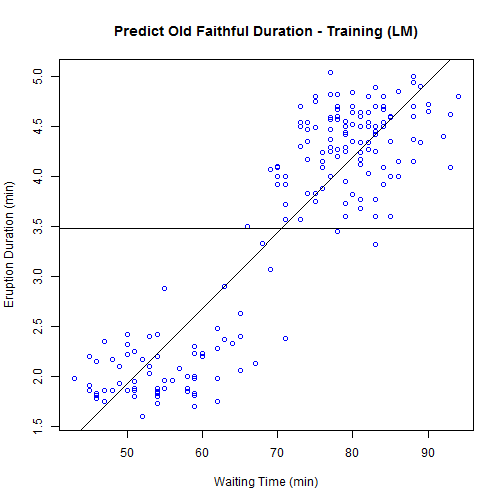

```r
# Training (LM)
eruption.lm1 <- lm(eruptions ~ waiting, data=trainFaith)
plot(trainFaith$waiting,trainFaith$eruptions,ylab = "Eruption Duration (min)", xlab = "Waiting Time (min)"
     ,col = "blue", main = "Predict Old Faithful Duration - Training (LM)")
abline( eruption.lm1, col = "black",lwd=1)
abline(mC <- lm(eruptions ~ 1, data = trainFaith))
```

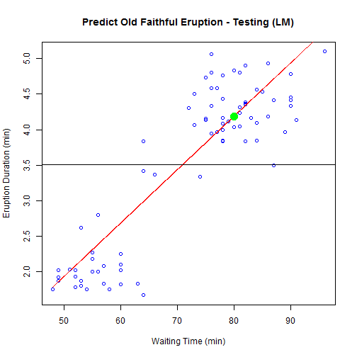

```r
# Testing (LM)
plot(testFaith$waiting,testFaith$eruptions,ylab = "Eruption Duration (min)", xlab = "Waiting Time (min)"
     ,col = "blue", main = "Predict Old Faithful Eruption - Testing (LM)")
lines(testFaith$waiting,pred1 <- predict(eruption.lm1,newdata = testFaith),lwd=1,col="red")
abline(mC <- lm(eruptions ~ 1, data = testFaith))
waiting <- 80
newdata <- data.frame(waiting = 80) #wrap the parameter
coeffs <- coefficients(eruption.lm1)
duration1 <- coeffs[1] + coeffs[2]*waiting
points(waiting,duration1, col = "green", pch = 16, cex = 2)
```

```r
pred1 <- duration1
pred1
```

```
(Intercept)
   4.189545
```

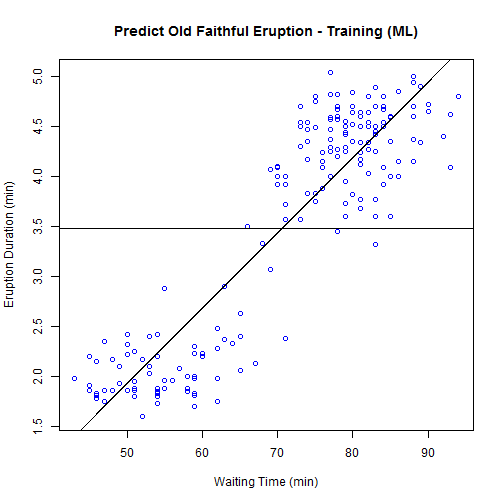

```r
#Training - ML

eruption.lm2 <- train(eruptions ~ waiting,data=trainFaith,method="rlm")

plot(trainFaith$waiting,trainFaith$eruptions,ylab = "Eruption Duration (min)", xlab = "Waiting Time (min)"
     ,col = "blue", main = "Predict Old Faithful Eruption - Training (ML)")
lines(trainFaith$waiting,predict(eruption.lm2),lwd=1)
abline(mC <- rlm(eruptions ~ 1, data = trainFaith))
```

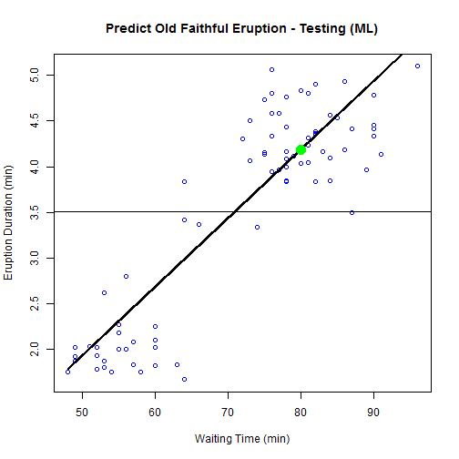

```r
# Testing - ML
plot(testFaith$waiting,testFaith$eruptions,ylab = "Eruption Duration (min)", xlab = "Waiting Time (min)"
     ,col = "blue", main = "Predict Old Faithful Eruption - Testing (ML)")
lines(testFaith$waiting,pred2 <- predict(eruption.lm2,newdata = testFaith),lwd=2,col="black")
abline(mC <- lm(eruptions ~ 1, data = testFaith))

newdata <- data.frame(waiting = 80) #wrap the parameter
#Then we apply the predict function to eruption.lm along with newdata.
duration2 <- predict(eruption.lm2,newdata) #apply predict
points(waiting,duration2, col = "green", pch = 16, cex = 2)
```

```r
pred2 <- duration2
pred2
```

```
       1
4.189574
```